# Cyclistic Member vs Casual Rider Useage Pattern

Muhammad Ahmed

3rd of October 2024

This project was undertaken as part of the Google Professional Certification, Introduction to Data Analytics. Let’s dive in!

## Introduction

Initially I had thought to clean data in SQL and then use Tableau for graphics, however, due to the limits in BigQuery and Tableau Public, I decided to use R

## Background

I am a junior data analyst working on the marketing analyst team at Cyclistic, a bike-share company in Chicago. The director of marketing believes the company’s future success depends on maximizing the number of annual memberships. Therefore, my team wants to understand how casual riders and annual members use Cyclistic bikes differently. From theseinsights, my team will design a new marketing strategy to convert casual riders into annual members. But first, Cyclistic executives must approve your recommendations, so they must be backed up with compelling data insights and professional data visualizations

## ASK

In this regards, the marketing department is tasked with 3 questions to answer *How do annual members and casual riders use Cyclistic bikes differently?* Why would casual riders buy Cyclistic annual memberships? *How can Cyclistic use digital media to influence casual riders to become members?

I am assigned a task my the marketing department director(Lily Moreno) : How do annual members and casual riders use Cyclistic bikes differently?

## Prepare DATA

### Loading necessary libraries

```r
library(tidyverse)
library(janitor)
```

```r
library(lubridate)
library(dplyr)
library(ggplot2)
```

### Loading Files

```r
###Working directory was set from GUI, this was to confirm
getwd()
```

```
## [1] "C:/Users/mahme/Desktop/Data/Google Data Analytics Capstone project/Google Data Analytics Capstone project"
```

```r
###Read CSV Function for importing files, each month assigned as M(number)
###Latest data first, 202406 and onwards had time in different format
M1 <- read.csv('202405-divvy-tripdata.csv', header=TRUE)
M2 <- read.csv('202404-divvy-tripdata.csv', header=TRUE)
M3 <- read.csv('202403-divvy-tripdata.csv', header=TRUE)
M4 <- read.csv('202402-divvy-tripdata.csv', header=TRUE)
M5 <- read.csv('202401-divvy-tripdata.csv', header=TRUE)
M6 <- read.csv('202312-divvy-tripdata.csv', header=TRUE)
M7 <- read.csv('202311-divvy-tripdata.csv', header=TRUE)
M8 <- read.csv('202310-divvy-tripdata.csv', header=TRUE)
M9 <- read.csv('202309-divvy-tripdata.csv', header=TRUE)
M10 <- read.csv('202308-divvy-tripdata.csv', header=TRUE)
M11 <- read.csv('202307-divvy-tripdata.csv', header=TRUE)
M12 <- read.csv('202306-divvy-tripdata.csv', header=TRUE)

####Now this might not be an efficient method but for now, this is how I did it

###Combined all data frames into one for analysis
bike_rides <- rbind(M1,M2,M3,M4,M5,M6,M7,M8,M9,M10,M11,M12)

###Checking the dimensions of this whole thing
dim(bike_rides)
```

```
## [1] 5743278      13
```

### Cleaning Data

The following code is run to clean data. First, empty columns and rows are removed.

The start and end times are converted into the ymd_hms format (for calculations). The difftime function is used to calculate the time difference. To ensure that data is upto standards, we remove non finite values as well as values below 1 minute (negative and start stops) as well as longer than a day (user forgot to turn off bike etc.)

We also removed the data where start and end stations are missing.

We also extract the months and days from the data (as we will be using this further) and assign them to a new column of month and day respectively. In the end, all the processed and clean data is shifted into a new data frame bike_rides_clean.

```r
###This part removes empty columns and rows
bike_rides <- janitor::remove_empty(bike_rides,which=c("cols"))
bike_rides <- janitor::remove_empty(bike_rides,which=c("rows"))

###Converting Data/Time from chr to Date/Time format and assigning new columns
bike_rides$start_time <- lubridate::ymd_hms(bike_rides$started_at)
bike_rides$end_time <- lubridate::ymd_hms(bike_rides$ended_at)

###Calculating the difference in time
bike_rides$ride_time <- difftime(bike_rides$end_time,bike_rides$start_time,units="mins")

###Remove rows where ride_time has non-finite values (NA, NaN, Inf)
bike_rides_clean <- bike_rides %>%
  filter(is.finite(ride_time))

###Ensure the ride_time column is numeric (difftime can sometimes cause issues with plotting)
bike_rides$ride_time <- as.numeric(bike_rides$ride_time)

bike_rides <- bike_rides %>%
  filter(!is.na(start_station_name) & start_station_name != "",
         !is.na(end_station_name) & end_station_name != "")

###Removing Bike Rides less than a minute and more than a day
bike_rides_clean <- bike_rides %>%
  filter(ride_time >= 1 & ride_time <= 1440)

###Check the summary to understand the range of ride_time
summary(bike_rides_clean$ride_time)
```

```
##     Min.  1st Qu.   Median     Mean  3rd Qu.     Max.
##    1.000    5.933   10.183   16.573   18.083 1439.867
```

```r
###Month and Year extracted from start time for analysis
bike_rides_clean$ride_month <- format(bike_rides_clean$start_time, "%Y-%m")
###Extract the day of the week from the start time
bike_rides_clean$day_of_week <- wday(bike_rides_clean$start_time, label = TRUE, abbr = FALSE)

###Checking Dimensions again to see if any empty rows or columns were removed
dim(bike_rides_clean)
```

```
## [1] 4237943      18
```

```r
###Count the number of rides per month for each user type
rides_per_month <- bike_rides_clean %>%
  group_by(ride_month, member_casual) %>%
  summarise(total_rides = n()) %>%
  ungroup()
```

## Analyzing the DATA

### Daily Rides Breakdown

This chunk of code is used to count the number of rides per day of the week for each user type

```r
rides_per_day <- bike_rides_clean %>%
  group_by(day_of_week, member_casual) %>%
  summarise(total_rides = n()) %>%
  ungroup()
```

View the result

```r
print(rides_per_day)
```

```
## # A tibble: 14 × 3
##    day_of_week member_casual total_rides
##    <ord>       <chr>               <int>
##  1 Sunday      casual             248659
##  2 Sunday      member             297532
##  3 Monday      casual             175079
##  4 Monday      member             389953
##  5 Tuesday     casual             168580
##  6 Tuesday     member             428323
##  7 Wednesday   casual             173416
##  8 Wednesday   member             442027
##  9 Thursday    casual             186681
## 10 Thursday    member             445900
## 11 Friday      casual             223017
## 12 Friday      member             395387
## 13 Saturday    casual             314526
## 14 Saturday    member             348863
```

This chunk of code gives the plot for the the number of rides per day of the week for each user type

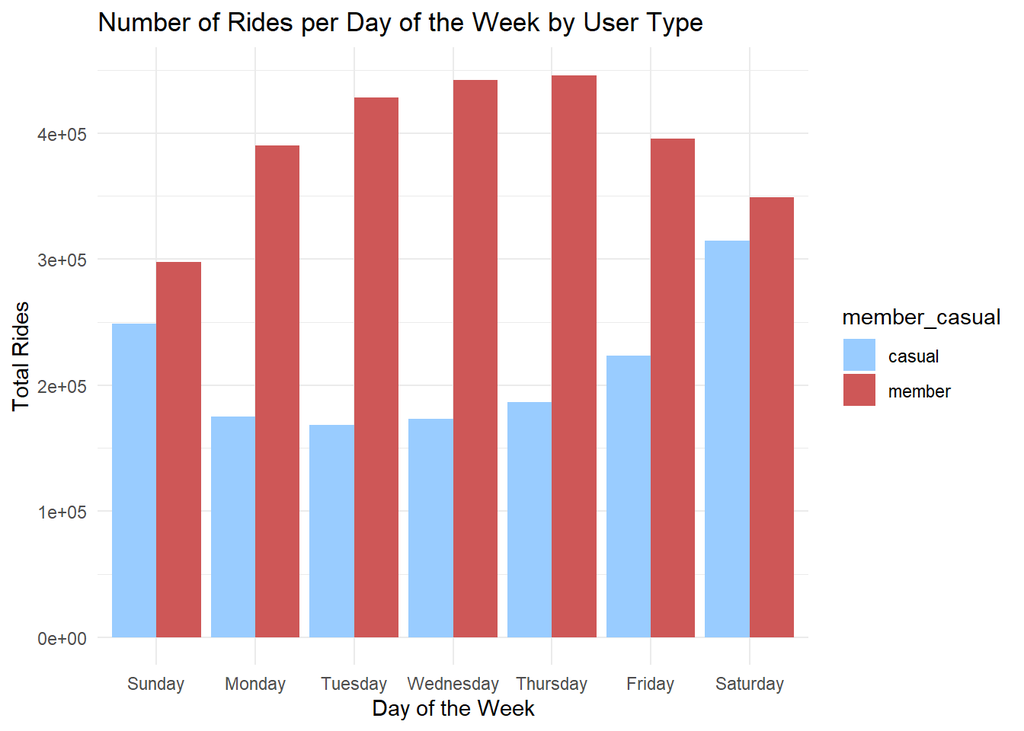

### Monthly Breakdown - Riders Type

```r
###View result
print(rides_per_month)
```

```
## # A tibble: 24 × 3
##    ride_month member_casual total_rides
##    <chr>      <chr>               <int>
##  1 2023-06    casual             215923
##  2 2023-06    member             308794
##  3 2023-07    casual             240949
##  4 2023-07    member             321967
##  5 2023-08    casual             230213
##  6 2023-08    member             344300
##  7 2023-09    casual             193977
##  8 2023-09    member             304187
##  9 2023-10    casual             128313
## 10 2023-10    member             268639
## # ℹ 14 more rows
```

```r
###Define pastel colors for types of users
color_palettes <- c("member" = "#CE5760", "casual" = "#99CCFF")  # Pastel red and blue
```

The results are as follows:

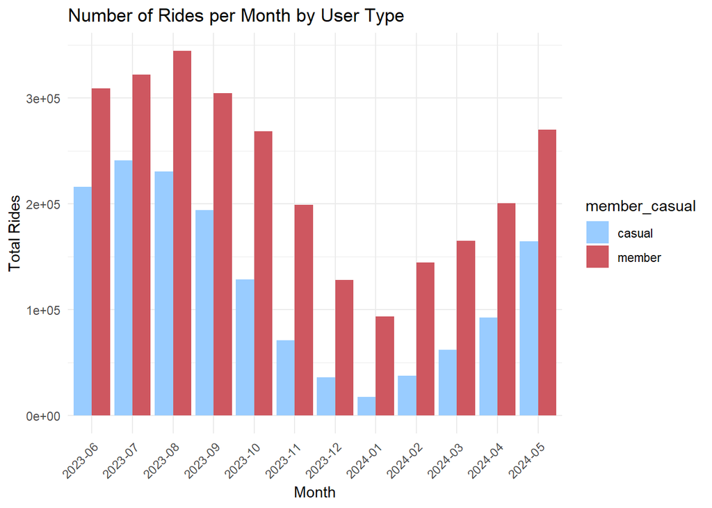

### Time spent riding bikes by user type

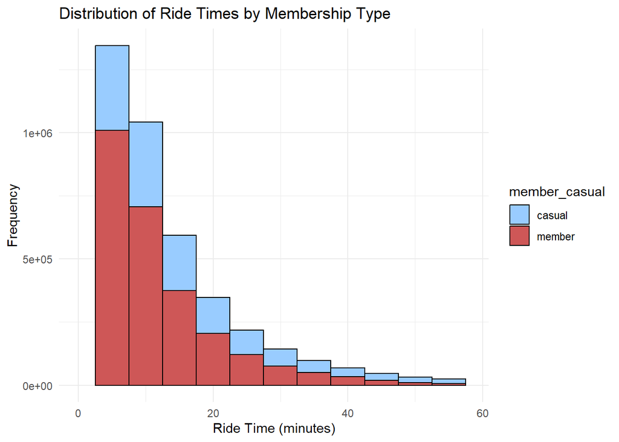

### Bike Ridership at different hours of the day

Extract the hour of the start time for analysis

```r
bike_rides_clean$start_hour <- hour(bike_rides_clean$start_time)
```

Data Plot

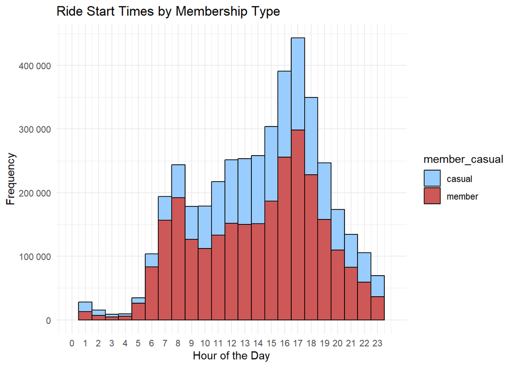

### Most Frequented Stations by user type

The following code is used to differentiate the most used start and stop stations, filtered by month and user type

```r
###Group by month, user type, and start station, count rides
most_used_start_stations <- bike_rides_clean %>%
  group_by(ride_month, member_casual, start_station_name) %>%
  summarise(total_rides = n()) %>%
  arrange(ride_month, member_casual, desc(total_rides)) %>%
  group_by(ride_month, member_casual) %>%
  slice_max(total_rides, n = 5)  ####Top 5 stations
###Group by month, user type, and end station, count rides
most_used_end_stations <- bike_rides_clean %>%
  group_by(ride_month, member_casual, end_station_name) %>%
  summarise(total_rides = n()) %>%
  arrange(ride_month, member_casual, desc(total_rides)) %>%
  group_by(ride_month, member_casual) %>%
  slice_max(total_rides, n = 5)  ####Top 5 stations
```

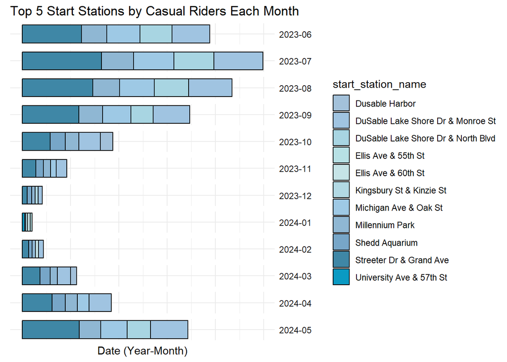

```r
# Define 11 pastel blue colors
pastel_blue_colors <- c(
  "#A3C1DA", "#A0C4E1", "#A8D5E2", "#B7E1E5", "#C6E4E7",
  "#B2D9E4", "#9EC9E5", "#8FB7D3", "#77A6C8", "#3F87A6",
  "#0A9AC3", "#0A8AD3", "#016CC3", "#024CC3", "#011CC1"
)

### Start station plot for casual riders with horizontal facet labels
ggplot(most_used_start_stations %>% filter(member_casual == "casual"),
       aes(x = "", y = total_rides, fill = start_station_name)) +
  geom_bar(stat = "identity", width = 1, color = "black") +
  facet_wrap(~ride_month, ncol = 1, strip.position = "right") +
  coord_flip() +
  labs(title = "Top 5 Start Stations by Casual Riders Each Month",
       y = "Date (Year-Month)",
       x = NULL) +
  scale_fill_manual(values = pastel_blue_colors) +
  theme_minimal() +
  theme(
    strip.text.y = element_text(angle = 0),
    axis.text.x = element_blank(),
    axis.ticks.x = element_blank(),
    legend.position = "right"
  )
```

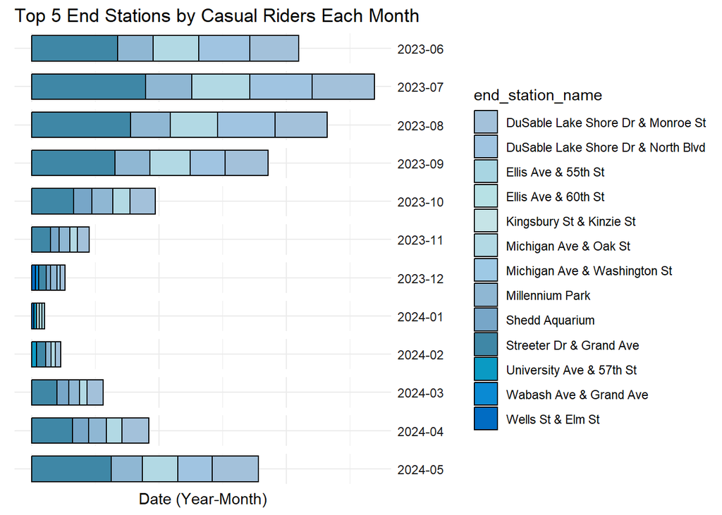

```r
### End station plot for casual riders with horizontal facet labels
ggplot(most_used_end_stations %>% filter(member_casual == "casual"),
       aes(x = "", y = total_rides, fill = end_station_name)) +
  geom_bar(stat = "identity", width = 1, color = "black") +
  facet_wrap(~ride_month, ncol = 1, strip.position = "right") +
  coord_flip() +
  labs(title = "Top 5 End Stations by Casual Riders Each Month",
       y = "Date (Year-Month)",
       x = NULL) +
  scale_fill_manual(values = pastel_blue_colors) +
  theme_minimal() +
  theme(
    strip.text.y = element_text(angle = 0),
    axis.text.x = element_blank(),
    axis.ticks.x = element_blank(),
    legend.position = "right"
  )
```

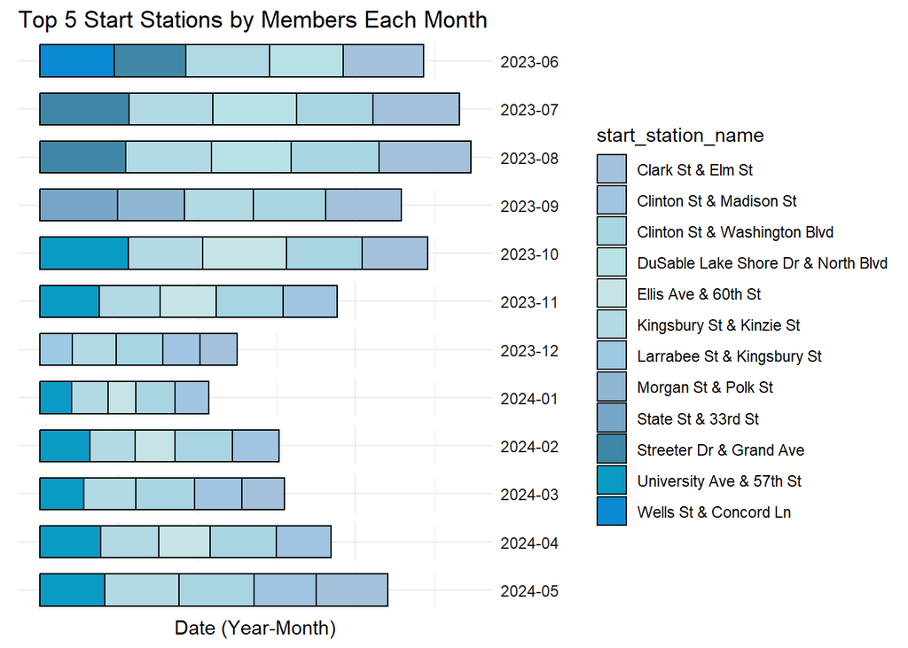

```r
### Start station plot for members with horizontal facet labels
ggplot(most_used_start_stations %>% filter(member_casual == "member"),
       aes(x = "", y = total_rides, fill = start_station_name)) +
  geom_bar(stat = "identity", width = 1, color = "black") +
  facet_wrap(~ride_month, ncol = 1, strip.position = "right") +
  coord_flip() +
  labs(title = "Top 5 Start Stations by Members Each Month",
       y = "Date (Year-Month)",
       x = NULL) +
  scale_fill_manual(values = pastel_blue_colors) +
  theme_minimal() +
  theme(
    strip.text.y = element_text(angle = 0),
    axis.text.x = element_blank(),
    axis.ticks.x = element_blank(),
    legend.position = "right"
  )
```

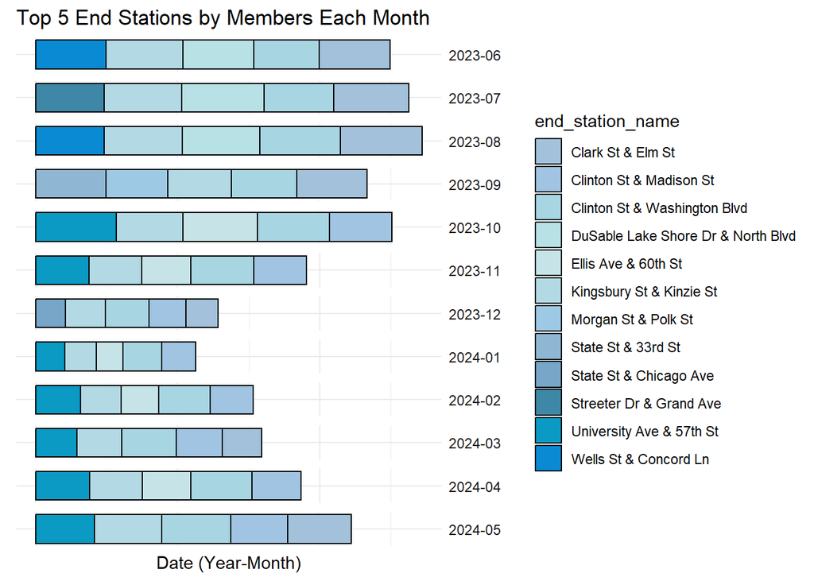

```r
### End station plot for members with horizontal facet labels
ggplot(most_used_end_stations %>% filter(member_casual == "member"),
       aes(x = "", y = total_rides, fill = end_station_name)) +
  geom_bar(stat = "identity", width = 1, color = "black") +
  facet_wrap(~ride_month, ncol = 1, strip.position = "right") +
  coord_flip() +
  labs(title = "Top 5 End Stations by Members Each Month",
       y = "Date (Year-Month)",
       x = NULL) +
  scale_fill_manual(values = pastel_blue_colors) +
  theme_minimal() +
  theme(
    strip.text.y = element_text(angle = 0),
    axis.text.x = element_blank(),
    axis.ticks.x = element_blank(),
    legend.position = "right"
  )
```

#### Stations as percentage of Total rides in given month

```r
###First, calculate the total rides per month for casual and member riders
total_rides_per_month <- bike_rides_clean %>%
  group_by(ride_month, member_casual) %>%
  summarize(total_rides_month = n())
###Calculate percentage for top 5 start stations
most_used_start_stations_percent <- most_used_start_stations %>%
  left_join(total_rides_per_month, by = c("ride_month", "member_casual")) %>%
  mutate(percent_rides = (total_rides / total_rides_month) * 100)

###Calculate percentage for top 5 end stations
most_used_end_stations_percent <- most_used_end_stations %>%
  left_join(total_rides_per_month, by = c("ride_month", "member_casual")) %>%
  mutate(percent_rides = (total_rides / total_rides_month) * 100)
```

Plotting the results

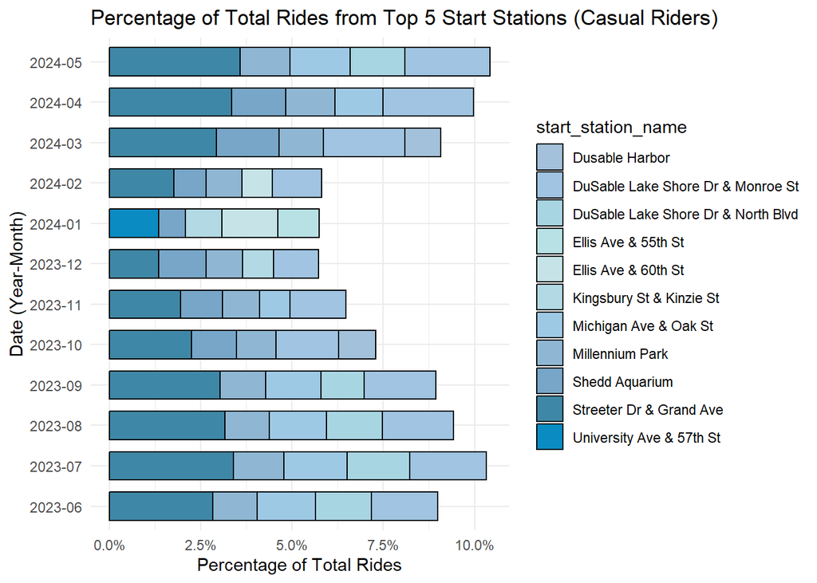

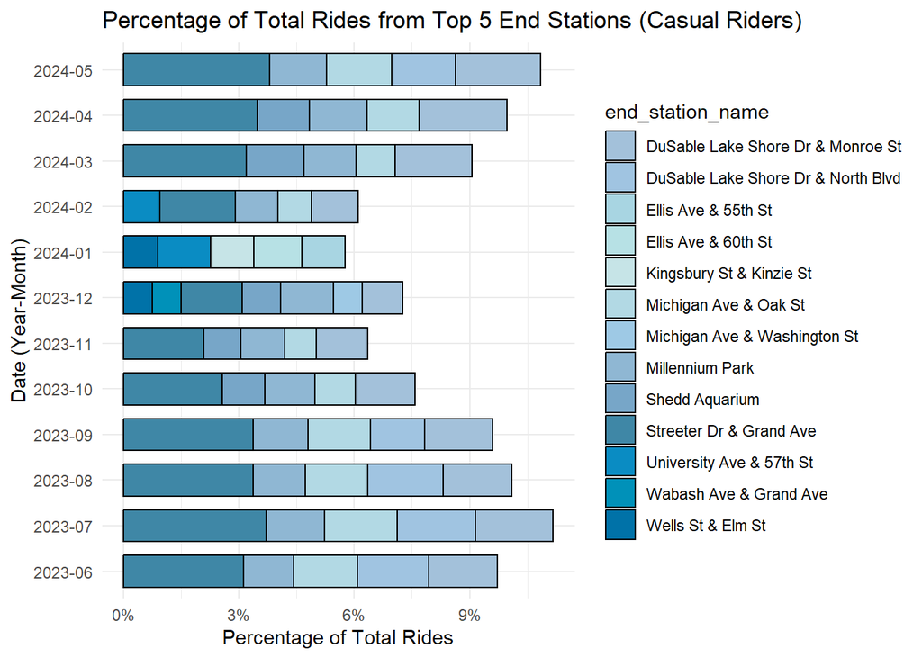

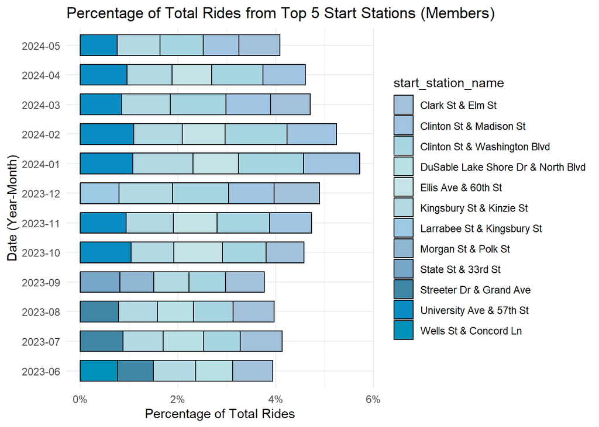

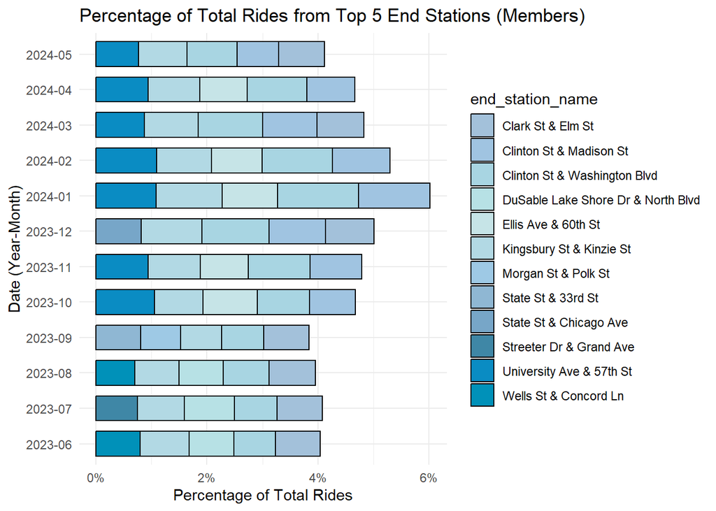

[figure not shown]

[figure not shown]

### Bike type used by each user type

The following code is used to find the useage of each bike type by the two types of users (member and casual)

```r
###Calculate the count of each rideable_type by member_casual
bike_usage_by_type <- bike_rides_clean %>%
  group_by(member_casual, rideable_type) %>%
  summarize(count = n()) %>%
  ungroup() %>%
  group_by(member_casual) %>%
  mutate(percent = count / sum(count) * 100)
```

```r
###Define pastel color palette for rideable types
rideable_color_palette <- c("electric_bike" = "#A2D1E6",
                            "docked_bike" = "#DDF0F7",
                            "classic_bike" = "#769FCA")

###Create a function to plot pie charts
plot_pie_chart <- function(data, user_type) {
  ggplot(data, aes(x = "", y = percent, fill = rideable_type)) +
    geom_bar(stat = "identity", width = 1, color = "black") +
    coord_polar("y") +
    labs(title = paste("Percentage of Rideable Types -", user_type)) +
    scale_fill_manual(values = rideable_color_palette) +  # Manual color scale for rideable types
    theme_void() +
    theme(legend.position = "right")  # Adjust legend position
}

###Separate data for members and casual riders
members_data <- bike_usage_by_type %>% filter(member_casual == "member")
casual_data <- bike_usage_by_type %>% filter(member_casual == "casual")
```

Plotting the results

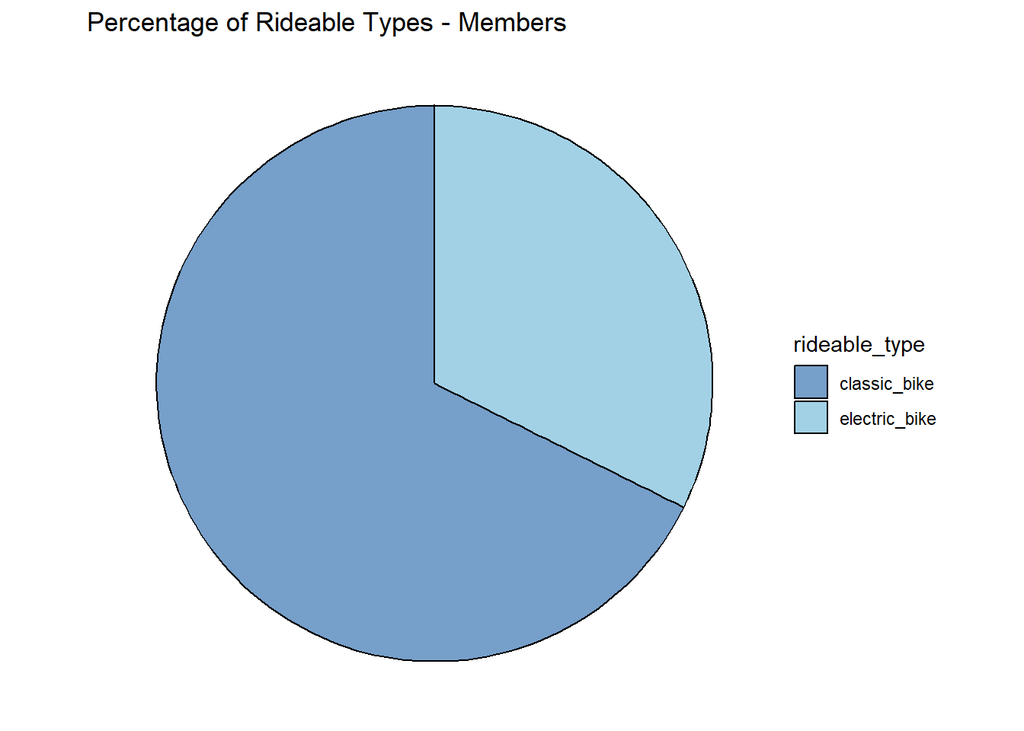

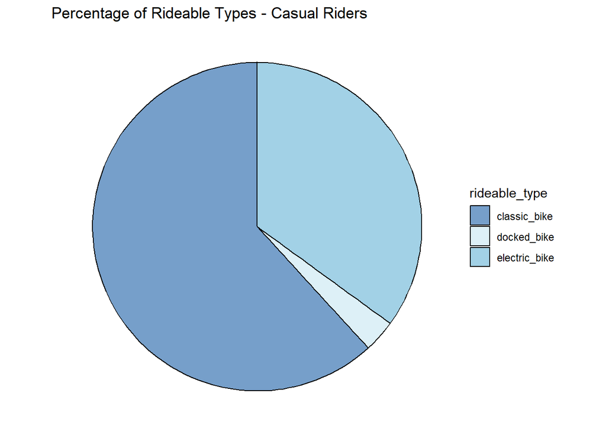